# PSet4

Note: Grading is based both on your graphs and verbal explanations. Follow all best practices *as discussed in class*, including choosing appropriate parameters for all graphs. *Do not expect the assignment questions to spell out precisely how the graphs should be drawn. Sometimes guidance will be provided, but the absense of guidance does not mean that all choices are ok.*

IMPORTANT: THIS TEMPLATE DOES NOT INCLUDE THE SAMPLE GRAPHS THAT APPEAR IN THE .HTML VERSION OF THE ASSIGNMENT SO BE SURE TO VIEW THAT FILE AS WELL.

### 1. `mycars` missing patterns

Create a missing values plot for the `mycars` dataset created below (slightly different from the one in the lecture slides). Your plot should be in the style of `extracat::visna()` (no longer available on CRAN) using **ggplot2** to create the main plot and two side plots and **patchwork** to put them together. It should show accurately: missing patterns, counts for missing by column and missing by pattern, and make it clear which row respresents complete cases. Bars in the side plots should be sorted and correspond to the rows and columns of the main plot. An example is provided though the aesthetics of your plot do not have to conform precisely to the example. Some code is provided to get you started with finding missing patterns. (Keep in mind that in the next question you will be turning this code into a function so to save yourself time later on write as generically as possible.)

```r
library(tidyverse)
library(patchwork)

# NA are being added to mtcars dataset
set.seed(5702)
mycars <- mtcars
mycars[1:25, "gear"] <- NA
mycars[10:20, 3:5] <- NA
for (i in 1:10) mycars[sample(32,1), sample(11,1)] <- NA
```

**Hints:**

- You can use this code to find and count the missing patterns:

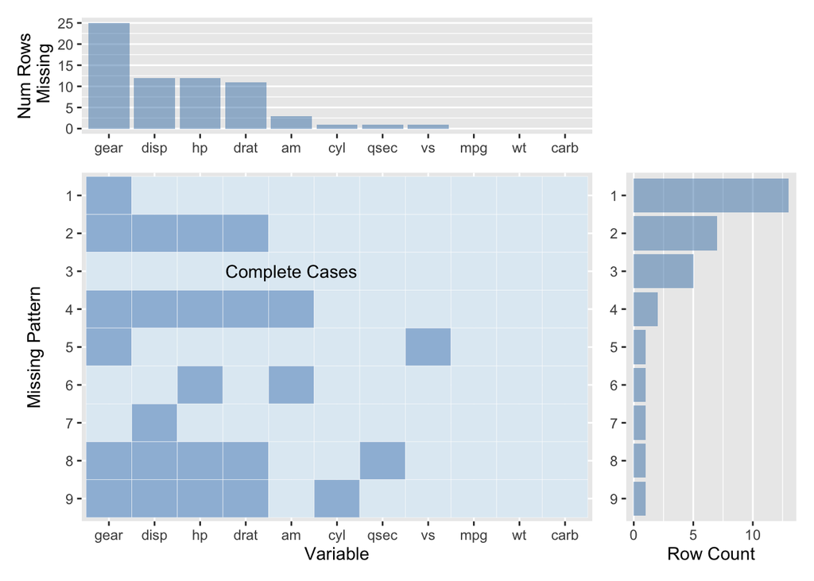

```r
#Creation of the Function
missing_plot_function <- function(data, per = FALSE){
     missing_patterns <- data.frame(is.na(data)) %>%
     group_by_all() %>%
     count(name = "count", sort = TRUE) %>%
     ungroup()

  # Sorting the missing patterns in Decreasing
  missing_patterns <- missing_patterns[order(missing_patterns$count, decreasing = TRUE), ]

  # Storing the sorted colnames in the variable sorted_colnames
  sorted_colnames <- colSums(is.na(data)) %>%
  sort(decreasing = TRUE)

  # Sorting again keeping the sorted colnames under consideration
  missing_patterns <- missing_patterns[, append(names(sorted_colnames), "count")]
        row_number <- which(!apply(as.data.frame(missing_patterns)[1:dim(missing_patterns)[2]-1], 1, any))

  # Rownames columns will serve as y-axis
  missing_patterns$rownames <- row.names(missing_patterns)

  # tidydata for plotting
  tidy_data <- missing_patterns %>%
               select(-count) %>%
               pivot_longer( -rownames, names_to = "Names", values_to = "Missing")

  # Plot the core missing value plot
  center_part <- tidy_data %>%
                 ggplot(aes(x = factor(Names, levels = names(sorted_colnames)),
                 y = fct_rev(factor(rownames, levels = missing_patterns$rownames)),
                 fill = Missing)) +
                 geom_tile(color = "white", show.legend = FALSE) +
                 annotate("text", x = dim(data)[2] %/% 2,y = nrow(missing_patterns) - row_number + 1,
                     label = "Complete Cases") +
                     scale_fill_brewer(palette = "BuPu") +
                     xlab("Variable") +
                     ylab("Missing Pattern")

  # Plot the missing values of a column
  top_df_part <- data.frame(as.list(sorted_colnames)) %>%
                 pivot_longer(everything(),names_to = "Names",values_to = "num_rows_missing")

  if (per) { top_df_part$num_rows_missing = top_df_part$num_rows_missing*100/nrow(data)}

  top_part <- top_df_part %>%
    ggplot(aes(x = factor(Names, levels = names(sorted_colnames)),
               y = num_rows_missing)) +
    geom_bar(stat = "identity",  fill = "steelblue", alpha=0.5) +
    xlab("Variable") +
    ylab(ifelse(per, "% Rows Missing", "Num Rows\n Missing"))+
     theme(axis.title.x =element_blank(),
                                    panel.grid.major.x = element_blank(),
                                    panel.grid.minor.x = element_blank())


  # plot the row count for patterns
  right_df_part <- missing_patterns

  if (per) {
    right_df_part$count = right_df_part$count*100/nrow(data)
  }

  right_part <- right_df_part %>%
    ggplot(aes(x = fct_rev(factor(rownames, levels = missing_patterns$rownames)),
               y = count)) +
    geom_bar(stat = "identity",  fill = "steelblue", alpha=0.5) +
    coord_flip() +
    xlab("Variable") +
    ylab(ifelse(per, "% Rows", "Row Count"))+
     theme(axis.title.y =element_blank(),
           panel.grid.major.y = element_blank(),
           panel.grid.minor.y = element_blank())


  design <- "
    1#
    23
  "

  top_part + center_part + right_part + plot_layout(design = design, widths = c(3,1), heights = c(1,3))
}


missing_plot_function(mycars, per = FALSE)
```

- To highlight the complete cases row you need a different fill scale than the one used to show missing vs. non-missing in the main plot (purple and grey in the example). This is a little tricky since you’re only allowed one fill scale in **ggplot2**. You can either use `alpha` to control the highlight with `scale_alpha_manual(values = ...)` or use the **ggnewscale** package which provides for multiple fill scales in the same graph.

### 2. Missing value plot function

You either put the function code in a separate `.R` file or include it in the `.Rmd` file.

```r
#Creation of the Function
missing_plot_function <- function(data, per = FALSE){
     missing_patterns <- data.frame(is.na(data)) %>%
     group_by_all() %>%
     count(name = "count", sort = TRUE) %>%
     ungroup()

  # Sorting the missing patterns in Decreasing
  missing_patterns <- missing_patterns[order(missing_patterns$count, decreasing = TRUE), ]

  # Storing the sorted colnames in the variable sorted_colnames
  sorted_colnames <- colSums(is.na(data)) %>%
  sort(decreasing = TRUE)

  # Sorting again keeping the sorted colnames under consideration
  missing_patterns <- missing_patterns[, append(names(sorted_colnames), "count")]
        row_number <- which(!apply(as.data.frame(missing_patterns)[1:dim(missing_patterns)[2]-1], 1, any))

  # Rownames columns will serve as y-axis
  missing_patterns$rownames <- row.names(missing_patterns)

  # tidydata for plotting
  tidy_data <- missing_patterns %>%
               select(-count) %>%
               pivot_longer( -rownames, names_to = "Names", values_to = "Missing")

  # Plot the core missing value plot
  center_part <- tidy_data %>%
                 ggplot(aes(x = factor(Names, levels = names(sorted_colnames)),
                 y = fct_rev(factor(rownames, levels = missing_patterns$rownames)),
                 fill = Missing)) +
                 geom_tile(color = "white", show.legend = FALSE) +
                 annotate("text", x = dim(data)[2] %/% 2,y = nrow(missing_patterns) - row_number + 1,
                     label = "Complete Cases") +
                     scale_fill_brewer(palette = "BuPu") +
                     xlab("Variable") +
                     ylab("Missing Pattern")

  # Plot the missing values of a column
  top_df_part <- data.frame(as.list(sorted_colnames)) %>%
                 pivot_longer(everything(),names_to = "Names",values_to = "num_rows_missing")

  if (per) { top_df_part$num_rows_missing = top_df_part$num_rows_missing*100/nrow(data)}

  top_part <- top_df_part %>%
    ggplot(aes(x = factor(Names, levels = names(sorted_colnames)),
               y = num_rows_missing)) +
    geom_bar(stat = "identity",  fill = "steelblue", alpha=0.5) +
    xlab("Variable") +
    ylab(ifelse(per, "% Rows Missing", "Num Rows\n Missing"))+
     theme(axis.title.x =element_blank(),
                                    panel.grid.major.x = element_blank(),
                                    panel.grid.minor.x = element_blank())


  # plot the row count for patterns
  right_df_part <- missing_patterns

  if (per) {
    right_df_part$count = right_df_part$count*100/nrow(data)
  }

  right_part <- right_df_part %>%
    ggplot(aes(x = fct_rev(factor(rownames, levels = missing_patterns$rownames)),
               y = count)) +
    geom_bar(stat = "identity",  fill = "steelblue", alpha=0.5) +
    coord_flip() +
    xlab("Variable") +
    ylab(ifelse(per, "% Rows", "Row Count"))+
     theme(axis.title.y =element_blank(),
           panel.grid.major.y = element_blank(),
           panel.grid.minor.y = element_blank())


  design <- "
    1#
    23
  "

  top_part + center_part + right_part + plot_layout(design = design, widths = c(3,1), heights = c(1,3))
}
```

2. Show the output for both options (counts / percent) for the `economics` dataset in the **ggplot2** package. (This is a test to see if your function works if there are no missing values.)

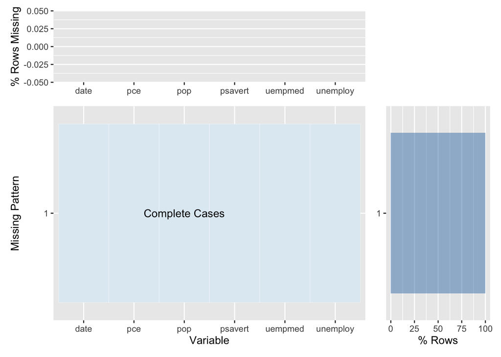

```r
missing_plot_function(economics, per = TRUE)
```

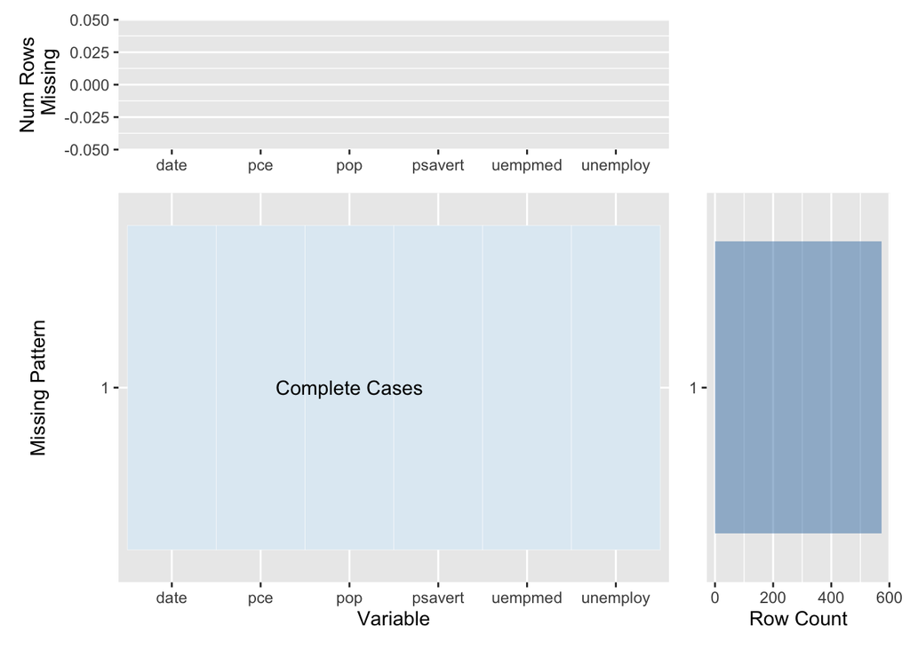

```r
missing_plot_function(economics, per = FALSE)
```

3. Show the output for both options (counts / percent) for the `HollywoodMovies2011` dataset in the **Lock5withR** package. You can shorten the column names so they don’t overlap in the plot.

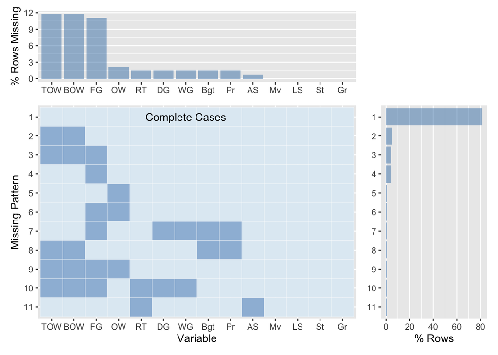

```r
library(Lock5withR)
data(HollywoodMovies2011)
names(HollywoodMovies2011) <- c("Mv", "LS", "RT", "AS", "St", "Gr", "TOW", "BOW",
                                "DG", "FG", "WG", "Bgt", "Pr", "OW")


missing_plot_function(HollywoodMovies2011, per = TRUE)
```

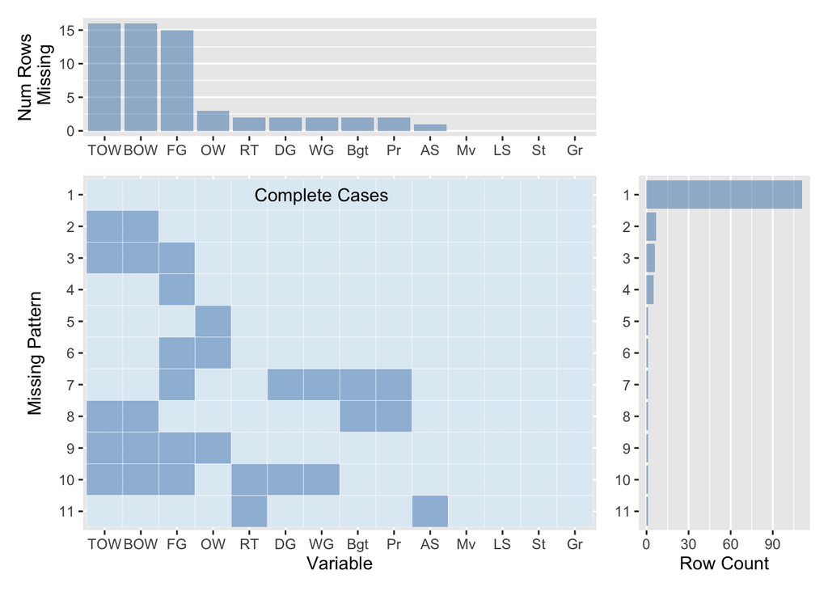

```r
missing_plot_function(HollywoodMovies2011, per = FALSE)
```

### 3. Setup your GitHub final project repo

1. Set up your final project repository following the [EDAVproject template](https://github.com/jtr13/EDAVtemplate). You can either choose one team member’s GitHub account, or create an organization to house the final project. *Be sure to follow all of the steps in the README so your bookdown book renders with your information, not the placeholders in the template.* Edit the link below to point to your rendered book:

https://github.com/virslaan/GoldenCross

2. Make sure that all team members have write access to the repository and have practiced making contributions. Edit the link below to point to your contributors page, showing that all team members have made contributions to the repo (Note that we do not have the ability to see who has write access, only who has contributed):

https://github.com/virslaan/GoldenCross/graphs/contributors

3. Discuss a plan for dividing up the work for the final project and briefly summarize what each person will do.

Planning is very necessary for any project development, we after looking at every ups and down of the project decided to make a perfect plan to use our skills to utiliza and make this project to be an awesome one. The Work respomsibilities were divided in such a way such that we could learn new skills along with data handling and implementation Zhaoyu Wu: Background Investigation and Data Collection. Vipul H Harihar: Data Collection, Github Mangemengemt, Data Auditing and Visualizations. Zhirui Yang: Data processing, Data Visualizations and Data Munging.

### 4. Missing values chapter

Write a first draft of the missing values chapter of your final project. You do not have to include all of the data you use in the final project. Choose one file and analyze it using techniques discussed in class for missing values. Include a plot using your function from Q2 as well as verbal interpretation of the plot. Edit this link to point to your chapter:

https://virslaan.github.io/GoldenCross/missing-values.html